# Cancer-related preprints during the COVID-19 pandemic

Maria Dermit

2020-08-21

# Impact of COVID-19 pandemic on cancer-related preprints.

It may seem evident that preprints have served as an unprecedent way of communicating scientific results during COVID-19 pandemic. I recently found a very interesting paper that investigates the attributes of COVID-19 preprints (including preprinting and publishing behaviour) and the impact of the pandemic on the scientific publishing landscape published in [bioarxiv](https://www.biorxiv.org/content/10.1101/2020.05.22.111294v1). After seeing this paper I wonder how much cancer-related preprints were affected during the pandemic ❓

```r
library(tidyverse)
library(rcrossref) # to access DOIs registered with Crossref
library(roadoi) # to link DOIs and open access versions of papers
library(rvest) # to Harvest (Scrape) Web Pages. Parsing of HTML/XML files
library(rentrez) # to get data from NCBI
library(XML) # to parse XML document
library(lubridate) # to deal with dates
```

To answer that question I am going to obtained data that expands from one year before the declaration of pandemic (that’s it from 31<sup>st</sup> December 2018) up to the day I started this analysis (18<sup>th</sup> August 2020). I am also going to use some of the functions the authors use in the paper that were made publicly available on [github.](https://github.com/preprinting-a-pandemic/pandemic_preprints)

### Retrieve preprint metadata via bioRxiv API

```r
max_results_per_page <- 100
base_url <- "https://api.biorxiv.org/details/"

start <- "2018-12-31"
end <- "2020-08-18"

getPreprintData <- function(server) {

  # Make initial request
  url <- paste0(base_url, server, "/", start, "/", end, "/", 0)
  request <- httr::GET(url = url)
  content <- httr::content(request, as = "parsed")

  # Determine total number of results and required iterations for paging
  total_results <- content$messages[[1]]$total
  pages <- ceiling(total_results / max_results_per_page) - 1

  data <- content$collection

  for (i in 1:pages) {
    cursor <- format(i * max_results_per_page, scientific = FALSE)
    # otherwise page 100000 becomes 1e05, which the api does not recognise
    url <- paste0(base_url, server, "/", start, "/", end, "/", cursor)
    request <- httr::RETRY("GET", url, times = 5, pause_base = 1,
                           pause_cap = 60) # retry if server error
    content <- httr::content(request, as = "parsed")
    if(content$messages[[1]]$status == "ok") {
      data <- c(data, content$collection)
    } else {
      data <- c(data, list("error" = content$messages[[1]]$status))
    }
    Sys.sleep(1)
  }
  return(data)
}
```

The we can retrieve data from biorxiv and medrxiv using the `getPreprintData` function.

```r
preprint_data <- purrr::map(c("biorxiv", "medrxiv"), getPreprintData)
```

This dataset is quite extensive, and retrieving all these data took a while to finish on my computer. Therefore, I am going to convert the obtained data into a tibble, do some transformations on it and safe the final tibble for future access.

```r
parsePreprintData <- function(item) {
  tibble(
    source = item$server,
    doi = item$doi,
    title = item$title,
    authors = item$authors,
    author_corresponding = item$author_corresponding,
    author_corresponding_institution = item$author_corresponding_institution,
    posted_date = item$date,
    version = item$version,
    license = item$license,
    type = item$type,
    category = item$category,
    abstract = item$abstract,
    is_published = item$published != "NA",
    published_doi = if(item$published == "NA") NA_character_ else item$published
  )
}

# Build a search string containing terms related to COVID-19
search_string_covid <- "coronavirus|covid-19|sars-cov|ncov-2019|
2019-ncov|hcov-19|sars-2"

# Build a search string containing terms related to cancer
search_string_cancer <- "cancer|tumor|adenocarcinoma|neoplasm|
carcinoma"

# Set date of first case of COVID-19
covid_start <- "2019-12-31"

# Parse data to dataframe
preprints_all <- map_dfr(preprint_data, ~ map_df(.x, parsePreprintData)) %>%
  group_by(doi) %>%
  # calculate number of versions of a preprint and number of authors
  mutate(n_versions = n()) %>%
  ungroup() %>%
  # keep the first version record
  filter(version == 1) %>%
  select(-version) %>%
  mutate(
    # clean up DOIs for later matching
    doi = str_trim(str_to_lower(doi)),
    published_doi = str_trim(str_to_lower(published_doi)),
    covid_preprint = case_when(
      str_detect(title, regex(search_string_covid, ignore_case = TRUE)) & posted_date > covid_start ~ "covid",
      str_detect(abstract, regex(search_string_covid, ignore_case = TRUE)) & posted_date > covid_start ~ "covid",
      str_detect(title, regex(search_string_cancer, ignore_case = TRUE))  ~ "cancer",
      str_detect(abstract, regex(search_string_cancer, ignore_case = TRUE)) ~ "cancer",
      T ~ "other"),
    n_authors = map_int(authors, ~length(strsplit(., split = ";")[[1]]))
    ) %>%
  # some duplicates are included
  distinct() %>%
  # reorder elements
  select(source, doi, posted_date, covid_preprint, title,
         abstract, n_versions, license, type, category, authors, n_authors,
         author_corresponding, author_corresponding_institution,
         is_published, published_doi)
```

```r
preprints_all %>%
    write_csv("data/preprints_basic_20181231_20200818.csv")
```

To safe the data and also be able to uploaded into Github (files size limit on Github is 100Mb), I am going to into split the data into two parts: -Preprints from 2018-12-31 before CV start 2019-12-31. -Preprints after CV start 2019-12-31 untill today 2020-08-18.

```r
  preprints_all %>%
  filter(posted_date <= "2019-12-31") %>%
  write_csv("data/preprints_basic_beforeCV_20181231_20191231.csv")
preprints_all %>%
  filter(posted_date >= "2019-12-31") %>%
  write_csv("data/preprints_basic_afterCV_20191231_20200818.csv")
```

We can read and merge these data together.

```r
preprints_bf<- read.csv("/Users/dermit01/Downloads/blog-master-1/data/preprints/preprints_basic_beforeCV_20181231_20191231.csv")
preprints_af<- read.csv("/Users/dermit01/Downloads/blog-master-1/data/preprints/preprints_basic_afterCV_20191231_20200818.csv")
preprints_all<-rbind(preprints_bf,preprints_af)
```

### Plotting the data

Let’s first inspect the number of cancer-related and covid-related preprints in the time span between 31<sup>st</sup> December 2018 up to 18<sup>th</sup> August 2020.

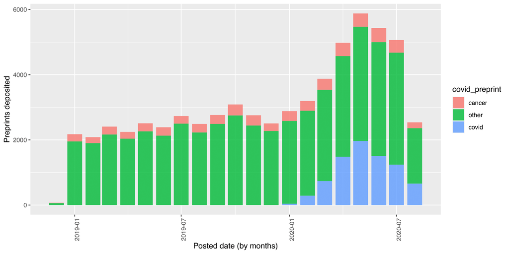

```r
preprints_all %>%
    mutate(posted_date = lubridate::ymd(posted_date)) %>%
  mutate(posted_month = floor_date(posted_date, unit = "month"))  %>%  group_by(covid_preprint,posted_month) %>% count() %>% mutate_if(is.character,as.factor)%>%
    ggplot(aes(x = posted_month, y = n, fill = covid_preprint))+
    geom_col(alpha=0.8)+
    labs(x = "Posted date (by months)", y = "Preprints deposited")+  theme(axis.text.x = element_text(angle = 90))
```

Wow! the number of COVID-19 preprints increased tremendously along with the expansion of COVID-19 pandemic, reaching up to 2,000 preprints deposited in May (see [`preprint surge`](https://www.nature.com/articles/d41586-020-01394-6)). Early in May, preprint servers enhanced their usual screening procedures for publishing scientific articles related to COVID-19, adopting some restrictive publication norms like putting a bar on manuscripts that are solely based on computational models, and this could be one of the causes behind that drop in COVID-19 preprints after May.

Nevertheless, the majority of preprints were neither cancer-related nor COVID-19-related preprints.

The number of cancer-related preprints did not decrease when the pandemic expanded, and if anything there is a trend for more cancer-related preprints during 2019 and 2020. Despite many of the labs (including mine) being closed on the second trimester of 2020, the number of cancer-related preprints did not decreased during early days of the pandemic. Researchers could have had more time to put together results for preprint publication. I wonder though, if any category within biology research was more affected than others 🤔.

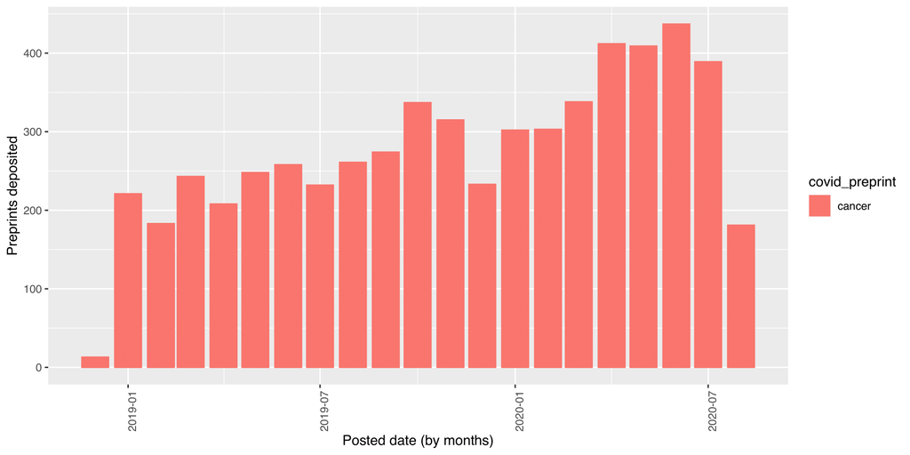

```r
preprints_all %>%
    mutate(posted_date = lubridate::ymd(posted_date)) %>%   mutate(posted_month = floor_date(posted_date, unit = "month"))  %>%  group_by(covid_preprint,posted_month) %>% count() %>% mutate_if(is.character,as.factor) %>% filter(covid_preprint=="cancer") %>%
   ggplot(aes(x = posted_month, y = n, color = covid_preprint))+
    geom_col(aes(fill = covid_preprint))+
  labs(x = "Posted date (by months)", y = "Preprints deposited")+  theme(axis.text.x = element_text(angle = 90))
```

How many of the preprints were later published in peer-review journals after WHO declared the outbreak of COVID-19 pandemic on the 11 of March 2020?

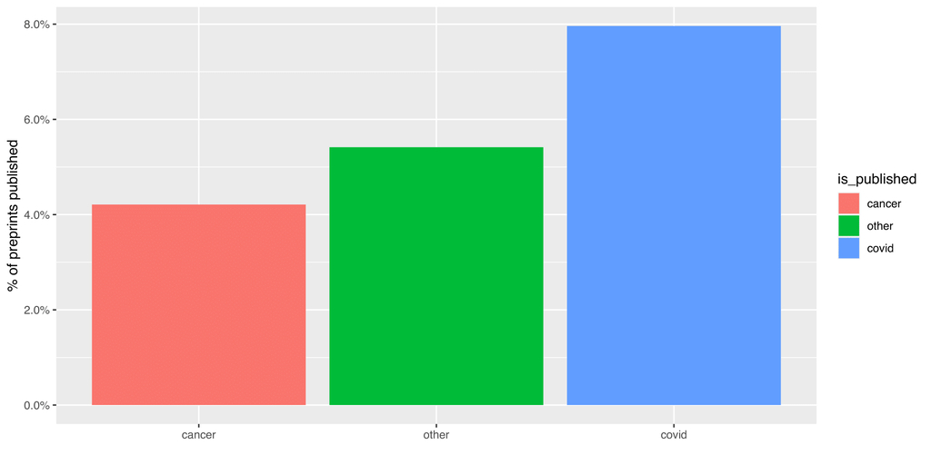

```r
preprints_all %>%
    mutate(posted_date = lubridate::ymd(posted_date)) %>%
    filter(posted_date >= "2020-03-11") %>%
    group_by(covid_preprint,is_published) %>%
    summarise(n = n()) %>%
    mutate(freq = n / sum(n)) %>%
filter(is_published!="FALSE") %>%
  ggplot(aes(x = covid_preprint, y = freq, fill = is_published))+
  geom_col(aes(fill = covid_preprint)) +
  scale_y_continuous(labels = scales::percent_format())+
    labs(x = "", y = "% of preprints published")
```

Almost double the number of COVID-19 preprints were published in peer-review journals upon preprint publication. This could have to do with the urgency of disseminating scientific knowledge of SAR-CoV2 virus pandemic and the little things known about SAR-CoV2 virus.

## Additional explorations on these data.

There are some additional exploration one could do with these data:

- **Percentage of downloads:** One could use the function `getUsageData` to get preprints metrics. Did scientist stopped downloading cancer-related preprints in favor of COVID-19 preprints or the number of cancer-related preprints downloads remained stable/grew during the pandemic?
- **Comments per preprint:** [Disqus](https://disqus.com) is a comment platform that allows readers to post text comments and is featured in BioRxiv and medRxiv html pages. In the [Fraser preprint](https://www.biorxiv.org/content/10.1101/2020.05.22.111294v1.full.pdf) authors found that non-COVID-19 preprints were rarely commented upon, in comparison to COVID-19 preprints (Fig 5D). One could explore if the engagement level of cancer-related preprints increased upon the outbreak of COVID-19 pandemic (if so, this could be because scientists that work in this research field would had have more office time to read and comment on these preprints).